# Homework 11

Author

Charles Rogers

## Question 1: Implementing K-means

### a. One iteration

I used seed `1101`. I generated the observations and randomly assigned them to two nonempty clusters.

**Show the solution code**

```r
set.seed(1101)
n <- 10
K <- 2
X <- matrix(rnorm(2 * n), nrow = n, ncol = 2)
initial <- sample(rep(seq_len(K), length.out = n))

cluster_means <- function(x, assignment, K) {
  means <- matrix(NA_real_, nrow = K, ncol = ncol(x))
  for (k in seq_len(K)) {
    if (any(assignment == k)) {
      means[k, ] <- colMeans(x[assignment == k, , drop = FALSE])
    }
  }
  means
}

means_initial <- cluster_means(X, initial, K)
distances <- sapply(seq_len(K), function(k) {
  rowSums((sweep(X, 2, means_initial[k, ], "-"))^2)
})
updated <- max.col(-distances, ties.method = "first")

data.frame(
  observation = seq_len(n),
  x1 = X[, 1],
  x2 = X[, 2],
  initial_cluster = initial,
  updated_cluster = updated
)
```

```
   observation         x1         x2 initial_cluster updated_cluster
1            1 -0.9575637  0.2125260               1               1
2            2 -0.2246695  1.2680507               2               2
3            3 -0.8709054 -0.7739969               1               1
4            4 -2.7133265  0.8276974               1               1
5            5  0.8983821 -1.2466796               1               2
6            6  0.7086123 -1.2757335               2               2
7            7 -0.1787092  0.8151773               1               2
8            8  0.1202973 -0.3928166               2               2
9            9 -0.5863690  1.4356798               2               2
10          10 -0.5473560  0.5236213               2               2
```

**Show the solution code**

```r
means_initial
```

```
           [,1]        [,2]
[1,] -0.7644245 -0.03305516
[2,] -0.1058970  0.31176033
```

The updated cluster means are calculated from the new assignments:

**Show the solution code**

```r
updated_means <- cluster_means(X, updated, K)
colnames(updated_means) <- c("x1", "x2")
updated_means
```

```
              x1         x2
[1,] -1.51393189 0.08874215
[2,]  0.02716973 0.16104277
```

**Show the solution code**

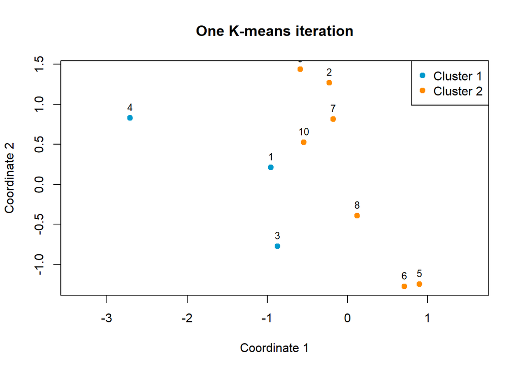

```r
plot(X, col = c("deepskyblue3", "darkorange")[updated],
     pch = 19, asp = 1, xlab = "Coordinate 1", ylab = "Coordinate 2",
     main = "One K-means iteration")
text(X, labels = seq_len(n), pos = 3, cex = 0.8)
legend("topright", legend = paste("Cluster", seq_len(K)),
       col = c("deepskyblue3", "darkorange"), pch = 19)
```

### b. A general K-means function

This function repeats the assignment and mean calculations. It works for any number of variables and keeps the old mean if a cluster becomes empty.

**Show the solution code**

```r
kmeans_manual <- function(x, K, assignment = NULL, max_iter = 100) {
  x <- as.matrix(x)
  if (!is.numeric(x) || any(!is.finite(x))) {
    stop("x must be a finite numeric matrix.")
  }
  n <- nrow(x)
  p <- ncol(x)
  if (K < 1 || K > n || K != as.integer(K)) {
    stop("K must be an integer between 1 and nrow(x).")
  }
  if (max_iter < 1 || max_iter != as.integer(max_iter)) {
    stop("max_iter must be a positive integer.")
  }

  if (is.null(assignment)) {
    assignment <- sample(rep(seq_len(K), length.out = n))
  }
  if (length(assignment) != n ||
      any(!is.finite(assignment)) ||
      any(assignment != as.integer(assignment)) ||
      any(assignment < 1 | assignment > K) ||
      any(tabulate(assignment, nbins = K) == 0)) {
    stop("assignment must be nonempty integer labels from 1 through K.")
  }

  means <- cluster_means(x, assignment, K)
  iterations <- 0L
  repeat {
    old_assignment <- assignment
    distances <- sapply(seq_len(K), function(k) {
      rowSums((sweep(x, 2, means[k, ], "-"))^2)
    })
    assignment <- max.col(-distances, ties.method = "first")
    new_means <- means
    for (k in seq_len(K)) {
      if (any(assignment == k)) {
        new_means[k, ] <- colMeans(x[assignment == k, , drop = FALSE])
      }
    }
    means <- new_means
    iterations <- iterations + 1L
    if (identical(assignment, old_assignment) || iterations >= max_iter) {
      break
    }
  }

  means <- cluster_means(x, assignment, K)
  for (k in seq_len(K)) {
    if (!any(assignment == k)) {
      means[k, ] <- new_means[k, ]
    }
  }
  wss <- sum(vapply(seq_len(K), function(k) {
    if (!any(assignment == k)) return(0)
    z <- sweep(x[assignment == k, , drop = FALSE], 2, means[k, ], "-")
    sum(z^2)
  }, numeric(1)))
  colnames(means) <- colnames(x)
  list(
    assignment = assignment,
    means = means,
    wss = wss,
    iterations = iterations
  )
}
```

### c. Two random initial assignments

I next used two different random starting assignments. The cluster labels themselves are arbitrary, so I compared the groupings rather than the labels.

**Show the solution code**

```r
same_partition <- function(a, b) {
  all(outer(a, a, "==") == outer(b, b, "=="))
}

set.seed(1102)
fit_1 <- kmeans_manual(X, K = 2,
                       assignment = sample(rep(1:2, length.out = n)))
set.seed(1103)
fit_2 <- kmeans_manual(X, K = 2,
                       assignment = sample(rep(1:2, length.out = n)))

fit_1$means
```

```
            [,1]       [,2]
[1,] -1.51393189 0.08874215
[2,]  0.02716973 0.16104277
```

**Show the solution code**

```r
fit_1$wss
```

```
[1] 13.27393
```

**Show the solution code**

```r
fit_2$means
```

```
           [,1]       [,2]
[1,] -0.8679990  0.8471254
[2,]  0.2140966 -0.9223067
```

**Show the solution code**

```r
fit_2$wss
```

```
[1] 7.948024
```

**Show the solution code**

```r
same_partition(fit_1$assignment, fit_2$assignment)
```

```
[1] FALSE
```

**Show the solution code**

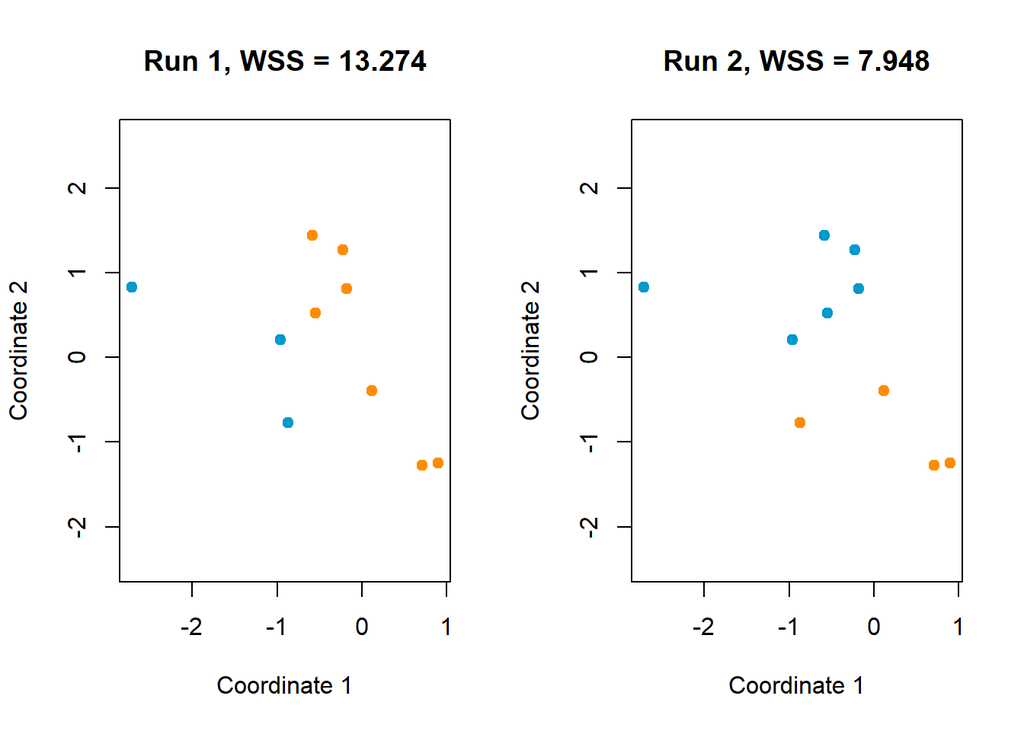

```r
par(mfrow = c(1, 2))
plot(X, col = c("deepskyblue3", "darkorange")[fit_1$assignment],
     pch = 19, asp = 1, xlab = "Coordinate 1", ylab = "Coordinate 2",
     main = paste("Run 1, WSS =", round(fit_1$wss, 3)))
plot(X, col = c("deepskyblue3", "darkorange")[fit_2$assignment],
     pch = 19, asp = 1, xlab = "Coordinate 1", ylab = "Coordinate 2",
     main = paste("Run 2, WSS =", round(fit_2$wss, 3)))
```

**Show the solution code**

```r
par(mfrow = c(1, 1))
```

The logical value tells whether the groupings are the same. The WSS values show the objective value for each run. Different starting values can give different local optima, so I would prefer the run with the smaller WSS.

## Question 2: Image color compression

For this question I made a simple reproducible color image with dimensions `160 x 120`. It has three RGB channels and is small enough for the repeated fits.

**Show the solution code**

```r
image_width <- 160
image_height <- 120
grid <- expand.grid(
  x = seq(0, 1, length.out = image_width),
  y = seq(0, 1, length.out = image_height)
)
red <- 0.15 + 0.85 * grid$y
green <- 0.08 + 0.55 * grid$y +
  0.20 * exp(-((grid$x - 0.70)^2 + (grid$y - 0.35)^2) / 0.025)
blue <- 0.15 + 0.70 * (1 - grid$y) +
  0.10 * sin(8 * pi * grid$x) * (1 - grid$y)
pixel_data <- matrix(
  pmin(1, pmax(0, cbind(red, green, blue))),
  ncol = 3
)
```

**Show the solution code**

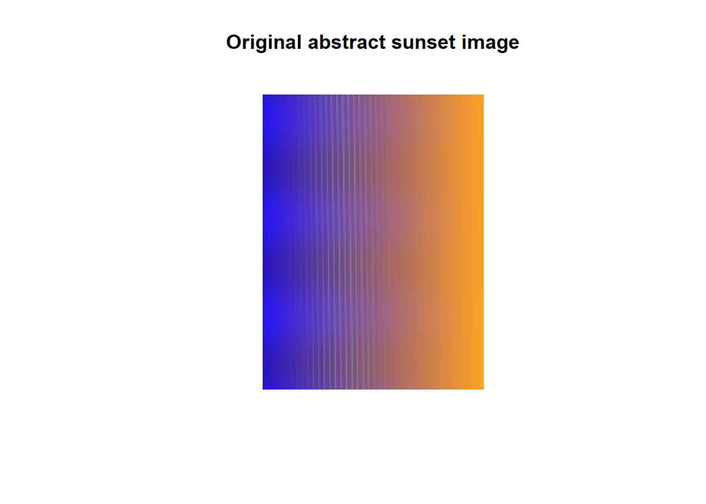

```r
image_colors <- matrix(
  rgb(pixel_data[, 1], pixel_data[, 2], pixel_data[, 3]),
  nrow = image_height, ncol = image_width
)
plot.new()
plot.window(xlim = c(0, 1), ylim = c(0, 1), asp = image_width / image_height)
rasterImage(image_colors, 0, 0, 1, 1, interpolate = FALSE)
title("Original abstract sunset image")
```

**Show the solution code**

```r
dim(image_colors)
```

```
[1] 120 160
```

**Show the solution code**

```r
dim(pixel_data)
```

```
[1] 19200     3
```

For each value of `K`, I used the function from Question 1. The output below gives the cluster RGB means and WSS.

**Show the solution code**

```r
K_values <- c(2, 3, 5, 10)
image_fits <- vector("list", length(K_values))
names(image_fits) <- paste0("K=", K_values)
for (j in seq_along(K_values)) {
  K_j <- K_values[j]
  set.seed(1120 + K_j)
  start_j <- sample(rep(seq_len(K_j), length.out = nrow(pixel_data)))
  image_fits[[j]] <- kmeans_manual(
    pixel_data, K = K_j, assignment = start_j, max_iter = 100
  )
}

image_wss <- data.frame(
  K = K_values,
  WSS = vapply(image_fits, function(fit) fit$wss, numeric(1))
)
image_wss
```

```
      K       WSS
K=2   2 681.31923
K=3   3 313.63952
K=5   5 138.55542
K=10 10  60.79952
```

**Show the solution code**

```r
for (j in seq_along(image_fits)) {
  cat("\nCluster means for", names(image_fits)[j], "\n")
  print(round(image_fits[[j]]$means, 4))
}
```

```
Cluster means for K=2
       [,1]   [,2]   [,3]
[1,] 0.7834 0.4946 0.3269
[2,] 0.3560 0.2399 0.6818

Cluster means for K=3
       [,1]   [,2]   [,3]
[1,] 0.2819 0.1795 0.7445
[2,] 0.8601 0.5396 0.2644
[3,] 0.5652 0.3797 0.5060

Cluster means for K=5
       [,1]   [,2]   [,3]
[1,] 0.3904 0.2701 0.6495
[2,] 0.7398 0.4629 0.3628
[3,] 0.9152 0.5751 0.2194
[4,] 0.2293 0.1365 0.7920
[5,] 0.5600 0.3813 0.5099

Cluster means for K=10
        [,1]   [,2]   [,3]
 [1,] 0.4637 0.4206 0.5981
 [2,] 0.6504 0.4122 0.4353
 [3,] 0.4327 0.2868 0.6107
 [4,] 0.2377 0.1421 0.7553
 [5,] 0.9521 0.5990 0.1892
 [6,] 0.3369 0.2231 0.6965
 [7,] 0.1918 0.1090 0.8660
 [8,] 0.5525 0.3627 0.5166
 [9,] 0.7511 0.4695 0.3537
[10,] 0.8507 0.5334 0.2720
```

**Show the solution code**

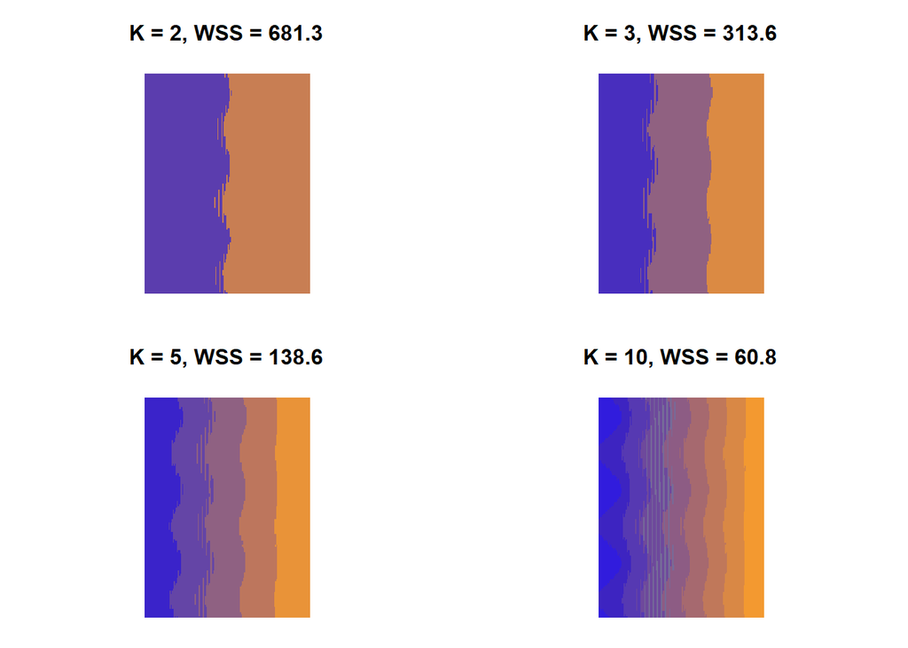

```r
compressed_colors <- lapply(image_fits, function(fit) {
  rgb(fit$means[fit$assignment, 1],
      fit$means[fit$assignment, 2],
      fit$means[fit$assignment, 3])
})
par(mfrow = c(2, 2), mar = c(1, 1, 3, 1))
for (j in seq_along(compressed_colors)) {
  compressed_image <- matrix(
    compressed_colors[[j]], nrow = image_height, ncol = image_width
  )
  plot.new()
  plot.window(xlim = c(0, 1), ylim = c(0, 1),
              asp = image_width / image_height)
  rasterImage(compressed_image, 0, 0, 1, 1, interpolate = FALSE)
  title(paste0("K = ", K_values[j], ", WSS = ",
               format(round(image_fits[[j]]$wss, 1), big.mark = ",")))
}
```

**Show the solution code**

```r
par(mfrow = c(1, 1))
```

I would choose `K = 5`. It keeps the main color changes while using fewer colors than `K = 10`. The WSS always decreases when `K` increases, but the images show less improvement after the main color regions have been captured.

## Question 3: Hierarchical clustering of cars

I used `car` only for labels and standardized the other variables before computing Euclidean distances.

**Show the solution code**

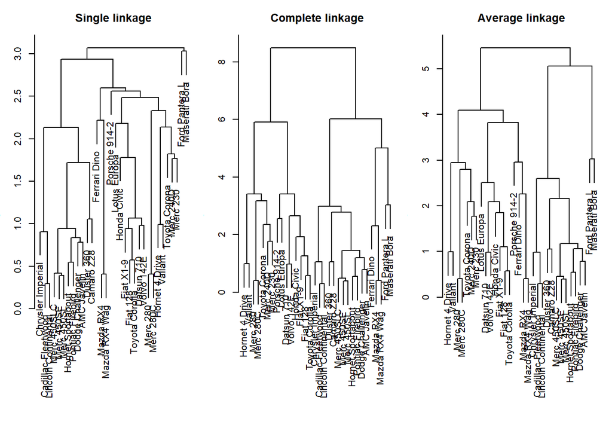

```r
cars <- read.csv("data/mtcars.csv", check.names = FALSE)
car_names <- cars$car
car_data <- cars[, setdiff(names(cars), "car")]
car_scaled <- scale(car_data)
car_distance <- dist(car_scaled, method = "euclidean")

hc_single <- hclust(car_distance, method = "single")
hc_complete <- hclust(car_distance, method = "complete")
hc_average <- hclust(car_distance, method = "average")

par(mfrow = c(1, 3), mar = c(3, 3, 3, 1))
plot(hc_single, labels = car_names, main = "Single linkage",
     xlab = "", sub = "")
plot(hc_complete, labels = car_names, main = "Complete linkage",
     xlab = "", sub = "")
plot(hc_average, labels = car_names, main = "Average linkage",
     xlab = "", sub = "")
```

**Show the solution code**

```r
par(mfrow = c(1, 1))
```

Single linkage can produce chaining, while complete linkage tends to produce more compact groups. Average linkage is between these two. I chose complete linkage and three clusters because the dendrogram gives a reasonable cut and the resulting groups are easy to interpret.

**Show the solution code**

```r
chosen_clusters <- cutree(hc_complete, k = 3)
membership <- data.frame(car = car_names, cluster = chosen_clusters)
membership[order(membership$cluster, membership$car), ]
```

```
                   car cluster
30        Ferrari Dino       1
29      Ford Pantera L       1
31       Maserati Bora       1
1            Mazda RX4       1
2        Mazda RX4 Wag       1
3           Datsun 710       2
18            Fiat 128       2
26           Fiat X1-9       2
19         Honda Civic       2
4       Hornet 4 Drive       2
28        Lotus Europa       2
9             Merc 230       2
8            Merc 240D       2
10            Merc 280       2
```

[output cut: 18 more lines]

**Show the solution code**

```r
cluster_means <- aggregate(
  car_data,
  by = list(cluster = chosen_clusters),
  FUN = mean
)
cluster_means
```

```
  cluster      mpg      cyl     disp        hp     drat       wt    qsec
1       1 18.50000 6.800000 223.4000 198.80000 3.836000 3.001000 15.6160
2       2 24.65333 4.533333 131.6467  91.33333 3.897333 2.579867 19.1580
3       3 15.05000 8.000000 357.6167 194.16667 3.120833 4.104083 17.1425
         vs        am     gear     carb
1 0.0000000 1.0000000 4.600000 5.200000
2 0.9333333 0.5333333 3.933333 1.800000
3 0.0000000 0.0000000 3.000000 3.083333
```

The cluster means show that one group contains smaller, more fuel-efficient cars, while another contains heavier cars with larger engines and lower MPG. The third group is more intermediate and includes some sporty cars. Standardization matters because otherwise variables such as displacement and horsepower would dominate the Euclidean distances simply because of their larger numerical scales.